# Data Access Capstone: Google Trends Project

Antonio Alaia

March 17, 2022

# 1 INTRODUCTION

## 1.1 Questions research

Inspired by a Rovetta A. study published on JMIR, the aim of this project is testing the hypothesis claiming that the volume of researches on Google Italia about right-wing topics, actors, websites and news has raised during the pandemic.

This project tries to answer a few questions:

1. Crossing date and hits variables, will we observe a positive linear trend?
2. Is there a seasonality to the queries?
3. Overall, how effective can be Google Trends on following socio-political movements?
- My research about the topic suggests me that lockdown and, more generally, COVID-19 Pandemic, have raised internet traffic and extremism has gained popularity among world citizens, therefore it’s likely that my plot visualization will show a positive linear trend.
- No prediction could be made for the first question, since that the answer could be affected by important socio-political events occurred during the pandemic or even changes in the lockdowns severity.
- Last question is a secondary quest I added for a more personal curiosity, so the answer will be more subjective and won’t be answered with a statistical approach but rather with a researcher point of view that is testing RStudio’s package *gtrendsR* and GoogleTrends for my socio-political studies!

## 1.2 Data and tool:*gtrendsR*

To test the hypotheses, I create a dataset that contains as many right-wing related keywords as possible. In order to do it, I start from a scraped list of organizations and people linked to right-wing parties and then look for related queries trying to identify the trending keywords among users.

The starting list is obtained by scraping an already existing map made by patriaindipendente.it. The best way to import a dataset with all trending searches on Google is by using Google Trends and, since I’m exclusively using RStudio to work on this project, I employ gtrendsR package (more info…). This package allows us to get a dataset with different variables: geo, time, keywords and onlyInterest (a boolean that allows to call ONLY the interest_over_time or not).

```r
library(tidyverse)
library(rvest)
library(stringr)
library(rio)
library(gtrendsR)
```

# 2 DATA IMPORT AND PREPARATION

## 2.1 First dataset

Firstly I imported the dataset by scraping a website (see the reference) and running the *gtrendsR* API to obtain the complete dataframe of the Google Trends statistics about a keyword. After I scraped the list, I had to replace all the keywords inside the gtrendsR argument *keyword*, set the *geo* variable as *“IT”* (Italy) and the period of time chosen for the study: *“2020-01-01 2022-02-28”*.

The first problem I encountered was the fact that the package’s argument *keyword* allows just 5 words at a time; to solve that issue, I created a function called *divideR* that allows me to divide the list in several groups of 5 so that I could automatically run one group of five at the time.

```r
divideR <- function(x,n) split(x, cut(seq_along(x), n, labels = FALSE))

dvd_listaNera <- divideR(scrap_listaNera, 7)

test1_listaNera <- gtrends(keyword = dvd_listaNera$'1',
                           geo = "IT",
                           time = "2020-01-01 2022-02-28"
)
test2_listaNera <- gtrends(keyword = dvd_listaNera$'2',
                           geo = "IT",
                           time = "2020-01-01 2022-02-28"
)
test3_listaNera <- gtrends(keyword = dvd_listaNera$'3',
                           geo = "IT",
                           time = "2020-01-01 2022-02-28"
)
test4_listaNera <- gtrends(keyword = dvd_listaNera$'4',
                           geo = "IT",
                           time = "2020-01-01 2022-02-28"
)
test5_listaNera <- gtrends(keyword = dvd_listaNera$'5',
                           geo = "IT",
                           time = "2020-01-01 2022-02-28"
)
test6_listaNera <- gtrends(keyword = dvd_listaNera$'6',
                           geo = "IT",
                           time = "2020-01-01 2022-02-28"
)
test7_listaNera <- gtrends(keyword = dvd_listaNera$'7',
                           geo = "IT",
                           time = "2020-01-01 2022-02-28"
)
test8_listaNera <- gtrends(keyword = c("8chan","8kun","pillola rossa",
                                       "olocausto italiano","grande sostituzione"),
                           geo = "IT",
                           time = "2020-01-01 2022-02-28"
)
```

After that, to enlarge my dataset, and to recreate the environment of a right-wing user that surfs the Internet binge-searching the related topics that the Google algorithm provides them, I create a first dataframe with the *related queries* that *gtrendsR* package found.

```r
list_1 <- test1_listaNera$related_queries$value
list_2 <- test2_listaNera$related_queries$value
list_3 <- test3_listaNera$related_queries$value
list_4 <- test4_listaNera$related_queries$value
list_5 <- test5_listaNera$related_queries$value
list_6 <- test6_listaNera$related_queries$value
list_7 <- test7_listaNera$related_queries$value

LIST <- c(list_1, list_2, list_3,list_4,list_5,list_6,list_7)

DATASET <- unique(LIST)
DATASET <- DATASET[-c(2,3,6,32,39,41,44,46,48,49,57,58,61,64:110)]
```

After some cleanings, I had my first list of *queries*. Then, I runned again *gtrendsR* but this time I only asked for *interest_over_time* by adding the argument *interestOnly=T*

```r
DATASET <- divideR(DATASET, 10)


group_1_onlytime <- gtrends(keyword = DATASET$'1',
                            geo = "IT",
                            time = "2020-01-01 2022-02-28",
                            onlyInterest = TRUE

)

#......
#From group_1_onlytime to group_10_onlytime: I cut the 8 groups in between for the
#sake of the reader of this report!
#......

group_10_onlytime <- gtrends(keyword = DATASET$'10',
                             geo = "IT",
                             time = "2020-01-01 2022-02-28",
                             onlyInterest = TRUE

)
```

## 2.2 Second dataset

Following the method above, I did the same for the second dataset, scraped from another list of keywords found online (see references). This time, my list was quite longer than the first so I had to use a for loop.

```r
download.file(url = nuova_lista,
              destfile = here::here("nuovaLista.html"))

scrap_nuovaLista <- read_html(here::here("nuovaLista.html")) %>%
  html_elements(css = "a") %>%
  html_text(trim = TRUE)

new_list <- unique(scrap_nuovaLista)
new_list <- new_list[-c(1)]

DATASET_2 <- vector()
v <- vector()

for (i in 1:446) {
  tryCatch({v <- gtrendsR::gtrends(keyword = new_list[i], geo = "IT", time = "2020-01-01 2022-02-28",
                                   onlyInterest = TRUE)},
           error = function(e){})
  cat(i, " ")
  v <- as.data.frame(v$interest_over_time)
  DATASET_2 <- rbind(DATASET_2, v)
}
```

Before merging the two dataset to create the final one, I had to clean the datasets with regex to delete the most general keywords and the other unrelated keywords that fell into the dataframe due to weird outcomes of the Google Algorithm. For the sake of the next regression, I had to cut all the values that fall below the *hits* = 5, and in the next part we’ll see what does it mean.

# 3 TEST AND VISUALIZATION

## 3.1 Is there a seasonality to the queries?

Having the full dataset for testing my hypothesis, I started with the first: is there a seasonality of the queries? Having the opportunity to cross *hits* that it’s a value that express the level of popularity of the term; when it’s 100 is the peak of popularity, whilst a value of 50 means that the term is half as popular. Scores of 0 mean that a sufficient amount of data was not available for the selected term.

To answer the first question, I did a density plot with *ggplot2*

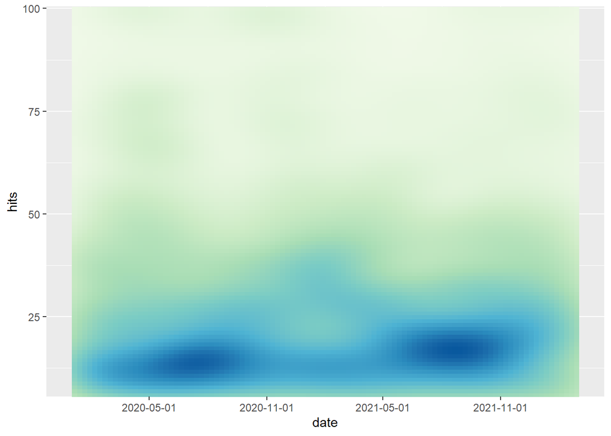

```r
COMPLETE_DATASET_regex <- import("Complete_dataset(cleanedREGEXS).csv")


density_plot <- ggplot(COMPLETE_DATASET_regex, aes(x=date, y=hits) ) +
  stat_density_2d(aes(fill = ..density..), geom = "raster", contour = FALSE) +
  scale_fill_distiller(palette=4, direction=1) +
  scale_x_datetime(date_breaks = "6 months") +
  scale_y_continuous(expand = c(0, 0)) +
  theme(
    legend.position='none'
  )

density_plot
```

As we can see, the plot shows that the first peak has been reached during the summer of 2020, between June and August 2020, while the seconds occurred between August and October 2021. Therefore, even if there isn’t a precise pattern that we can notice and can helps us making a prediction model, we can observe that the trending occurred just once a year; furthermore we can spot a little “cloud” during January-February 2021 that indicate a cluster of very trending queries.

## 3.2 Crossing date and hits: a positive linear trend?

For the second question, let’s have a look at the linear trend plot:

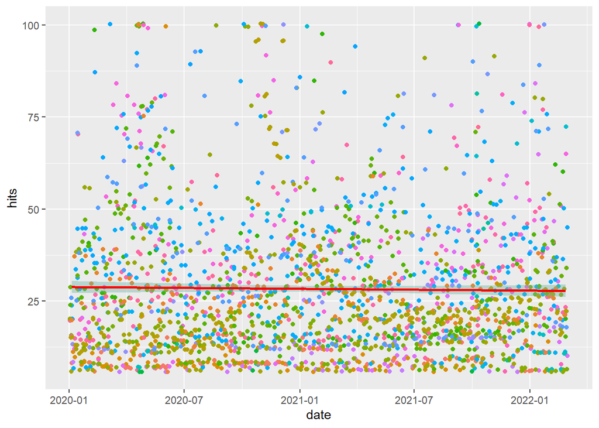

```r
COMPLETE_DATASET_regex <- import("Complete_dataset(cleanedREGEXS).csv")

linear_plot<- ggplot(COMPLETE_DATASET_regex, aes(x=date, y=hits) ) +
  geom_point(aes(date, hits,color = keyword), position = 'jitter') +
  geom_smooth(method=lm , color="red", fill="#69b3a2", se=TRUE) +
  theme(
    legend.position ='none')

linear_plot
```

# 4 Conclusion and personal considerations

## 4.1 Results comment

Despite the two peaks spotted while testing the presence of a seasonality about the queries, eventually I had to conclude that we can’t reject the null hypotheses for both questions, therefore our two alternative hypotheses are rejected since the results are statistically irrelevant.

There are several critical issues in my project, starting from the richness of the data to the statistical methods applied for testing the hypotheses, which could be implemented with further studies about the topic and the tools involved. For these reasons, I would rather focus on my *journey* and the impressions I had during my capstone research and the skills/tools involved. That’s why I wrote the next and last paragraph.

## 4.2 Third question research: opinion about *gtrendsR* and Google Trends

When I started my project I asked myself: could Google Trends be used to observe mass opinion and its shifting? So, I started looking for an API so I found *gtrendsR*. Given that I had just learnt to scrape from websites, I decided to enter the black galaxy of right-wing forums and social pages to obtain the largest dataset possible about slogans, topic, recurring keywords related to far right parties, organizations and communities. For example, I decided to scrape Stormfront, a famous forum populated by right sympathizers.

```r
stormfront <- read_html(here::here("Stormfront.html")) %>%
  html_elements(css = "#posts .alt1 a") %>%
  html_text(trim = TRUE)
view(stormfront)

stormfront <- c("Der Strumer in italiano", "ebrei nemico occulto", "giudeo bolscevismo",
                "piano giudaico massonico","internazionale ebraica",
                "der ewidge jude","forces occultes 1943","suss l’ebreo ",
                "banche ebraiche sovietici","ebreo lenin mente","questione ebraica","truffatori ebrei",
                "movimento omosessuale ebrei","il dividendo dei Rothschilds Waterloo",
                "mario monti ebrei","cospirazione kosher matthew hale","pericolo islam",
                "contro il filoislamismo","progetto grande califfato",
                "bibbia dell’antislamismo","il pericolo giallo","negrolandia inferno morti",
                "difendere identità biologica","diffondere identità razziale",
                "nazionalismo bianco","W.L. Pierce italiano","controllo giudaico mass media",
                "invasione allogeni","rhodesia paradiso a inferno",
                "11 settembre la verità","critiche globalizzazione","ida magli",
                "gilberto oneto bugie immigrati","pericolo rom",
                "druido verità piccone", "giorno memoria malattia mentale",
                "lorenzoni scritti essenziali",
                "protocolli sion falsi","miracolo economico hitler",
                "the colour of crime italiano","rushton razza","aplogruppi chi sono",
                "ebrei e sindrome Laron",
                "teorie Armand Marie Leroi","verità meticciato","Jared Tayler razza",
                "Genius Seculi","Giacinto auriti guerra sangue","Wissen Macht Frei in italiano",
                "American Dissident Voices ita","piano giudaico kalergi italiano",
                "savitri devi femminismo nazionalsocialismo")
```

I was very positive about the list I was creating, but then I had to give up because of Google Trends: the API was giving me back results about just the ~5% of the list of keywords due to lack of available data. This is one of the most critical issues about my research method, Google Trends is really sensitive and works better with maximum 2 words and preferably *non specific*.

Overall, I can consider myself quite satisfied about the new skills acquired during this project. Finally I had the chance to try my scraping skills, I had the chance to challenge myself and I enjoyed facing several critical issues, which I solved with regular expressions, new packages, for loops and a lot of data cleaning and preparation.

Despite the unresolving results obtained, I believe that this research could be a starting point for further analyses and a good capstone from which starting my data science and analysis career.

Antonio Alaia

# 5 References

- Rovetta A. “The Impact of COVID-19 on Conspiracy Hypotheses and Risk Perception in Italy: Infodemiological Survey Study Using Google Trends” JMIR Infodemiology 2021;1(1):e29929
- Davies G., Wu E. & Frank R. “A Witch’s Brew of Grievances: The Potential Effects of COVID-19 on Radicalization to Violent Extremism” Studies in Conflict & Terrorism; Taylor & Francis 1-24, 2021
- Singh K. “Effect of COVID-19 on Violent Extremism and Terrorism in Digital Spaces”, Centre for Air Power Studies (CAPS), December 2020
- [Patria Indipendente: Cronache dalla galassia nera](https://www.patriaindipendente.it/idee/copertine/cronache-dalla-galassia-nera/)